# Optimal Treatment Analysis

## Outcome Variable

**Outcome Variable:** whz

## Predictor Variables

**Intervention Variable:** brthmon

**Adjustment Set:**

unadjusted

## Stratifying Variables

The analysis was stratified on these variable(s):

- agecat
- studyid
- country

## Data Summary

| agecat | studyid | country | brthmon | n_cell | n |
| --- | --- | --- | --- | --- | --- |
| Birth | ki0047075b-MAL-ED | BANGLADESH | 1 | 19 | 241 |
| Birth | ki0047075b-MAL-ED | BANGLADESH | 2 | 23 | 241 |
| Birth | ki0047075b-MAL-ED | BANGLADESH | 3 | 22 | 241 |
| Birth | ki0047075b-MAL-ED | BANGLADESH | 4 | 21 | 241 |
| Birth | ki0047075b-MAL-ED | BANGLADESH | 5 | 20 | 241 |
| Birth | ki0047075b-MAL-ED | BANGLADESH | 6 | 10 | 241 |
| Birth | ki0047075b-MAL-ED | BANGLADESH | 7 | 19 | 241 |
| Birth | ki0047075b-MAL-ED | BANGLADESH | 8 | 23 | 241 |
| Birth | ki0047075b-MAL-ED | BANGLADESH | 9 | 19 | 241 |
| Birth | ki0047075b-MAL-ED | BANGLADESH | 10 | 24 | 241 |
| Birth | ki0047075b-MAL-ED | BANGLADESH | 11 | 15 | 241 |
| Birth | ki0047075b-MAL-ED | BANGLADESH | 12 | 26 | 241 |
| Birth | ki0047075b-MAL-ED | BRAZIL | 1 | 10 | 183 |
| Birth | ki0047075b-MAL-ED | BRAZIL | 2 | 18 | 183 |
| Birth | ki0047075b-MAL-ED | BRAZIL | 3 | 17 | 183 |
| Birth | ki0047075b-MAL-ED | BRAZIL | 4 | 9 | 183 |
| Birth | ki0047075b-MAL-ED | BRAZIL | 5 | 15 | 183 |
| Birth | ki0047075b-MAL-ED | BRAZIL | 6 | 8 | 183 |
| Birth | ki0047075b-MAL-ED | BRAZIL | 7 | 16 | 183 |
| Birth | ki0047075b-MAL-ED | BRAZIL | 8 | 17 | 183 |
| Birth | ki0047075b-MAL-ED | BRAZIL | 9 | 28 | 183 |
| Birth | ki0047075b-MAL-ED | BRAZIL | 10 | 17 | 183 |
| Birth | ki0047075b-MAL-ED | BRAZIL | 11 | 18 | 183 |
| Birth | ki0047075b-MAL-ED | BRAZIL | 12 | 10 | 183 |
| Birth | ki0047075b-MAL-ED | INDIA | 1 | 16 | 203 |
| Birth | ki0047075b-MAL-ED | INDIA | 2 | 16 | 203 |
| Birth | ki0047075b-MAL-ED | INDIA | 3 | 21 | 203 |
| Birth | ki0047075b-MAL-ED | INDIA | 4 | 13 | 203 |
| Birth | ki0047075b-MAL-ED | INDIA | 5 | 7 | 203 |
| Birth | ki0047075b-MAL-ED | INDIA | 6 | 18 | 203 |

[output cut: 834 more lines]

The following strata were considered:

- agecat: 24 months, studyid: ki0047075b-MAL-ED, country: BANGLADESH
- agecat: 24 months, studyid: ki0047075b-MAL-ED, country: BRAZIL
- agecat: 24 months, studyid: ki0047075b-MAL-ED, country: INDIA
- agecat: 24 months, studyid: ki0047075b-MAL-ED, country: NEPAL
- agecat: 24 months, studyid: ki0047075b-MAL-ED, country: PERU
- agecat: 24 months, studyid: ki0047075b-MAL-ED, country: SOUTH AFRICA
- agecat: 24 months, studyid: ki0047075b-MAL-ED, country: TANZANIA, UNITED REPUBLIC OF
- agecat: 24 months, studyid: ki1000108-CMC-V-BCS-2002, country: INDIA
- agecat: 24 months, studyid: ki1000108-IRC, country: INDIA
- agecat: 24 months, studyid: ki1017093-NIH-Birth, country: BANGLADESH
- agecat: 24 months, studyid: ki1066203-TanzaniaChild2, country: TANZANIA, UNITED REPUBLIC OF
- agecat: 24 months, studyid: ki1101329-Keneba, country: GAMBIA
- agecat: 24 months, studyid: ki1113344-GMS-Nepal, country: NEPAL
- agecat: 24 months, studyid: ki1114097-CMIN, country: BANGLADESH
- agecat: 24 months, studyid: ki1114097-CMIN, country: GUINEA-BISSAU
- agecat: 24 months, studyid: ki1114097-CMIN, country: PERU
- agecat: 24 months, studyid: ki1114097-CONTENT, country: PERU
- agecat: 24 months, studyid: ki1119695-PROBIT, country: BELARUS
- agecat: 24 months, studyid: ki1126311-ZVITAMBO, country: ZIMBABWE
- agecat: 24 months, studyid: ki1148112-LCNI-5, country: MALAWI
- agecat: 24 months, studyid: kiGH5241-JiVitA-3, country: BANGLADESH
- agecat: 24 months, studyid: kiGH5241-JiVitA-4, country: BANGLADESH
- agecat: 6 months, studyid: ki0047075b-MAL-ED, country: BANGLADESH
- agecat: 6 months, studyid: ki0047075b-MAL-ED, country: BRAZIL
- agecat: 6 months, studyid: ki0047075b-MAL-ED, country: INDIA
- agecat: 6 months, studyid: ki0047075b-MAL-ED, country: NEPAL
- agecat: 6 months, studyid: ki0047075b-MAL-ED, country: PERU
- agecat: 6 months, studyid: ki0047075b-MAL-ED, country: SOUTH AFRICA
- agecat: 6 months, studyid: ki0047075b-MAL-ED, country: TANZANIA, UNITED REPUBLIC OF
- agecat: 6 months, studyid: ki1000108-CMC-V-BCS-2002, country: INDIA
- agecat: 6 months, studyid: ki1000108-IRC, country: INDIA
- agecat: 6 months, studyid: ki1000109-EE, country: PAKISTAN
- agecat: 6 months, studyid: ki1000109-ResPak, country: PAKISTAN
- agecat: 6 months, studyid: ki1000304b-SAS-CompFeed, country: INDIA
- agecat: 6 months, studyid: ki1000304b-SAS-FoodSuppl, country: INDIA
- agecat: 6 months, studyid: ki1017093-NIH-Birth, country: BANGLADESH
- agecat: 6 months, studyid: ki1066203-TanzaniaChild2, country: TANZANIA, UNITED REPUBLIC OF
- agecat: 6 months, studyid: ki1101329-Keneba, country: GAMBIA
- agecat: 6 months, studyid: ki1112895-Guatemala BSC, country: GUATEMALA
- agecat: 6 months, studyid: ki1113344-GMS-Nepal, country: NEPAL
- agecat: 6 months, studyid: ki1114097-CMIN, country: BANGLADESH
- agecat: 6 months, studyid: ki1114097-CMIN, country: BRAZIL
- agecat: 6 months, studyid: ki1114097-CMIN, country: GUINEA-BISSAU
- agecat: 6 months, studyid: ki1114097-CMIN, country: PERU
- agecat: 6 months, studyid: ki1114097-CONTENT, country: PERU
- agecat: 6 months, studyid: ki1119695-PROBIT, country: BELARUS
- agecat: 6 months, studyid: ki1126311-ZVITAMBO, country: ZIMBABWE
- agecat: 6 months, studyid: ki1148112-LCNI-5, country: MALAWI
- agecat: 6 months, studyid: kiGH5241-JiVitA-3, country: BANGLADESH
- agecat: 6 months, studyid: kiGH5241-JiVitA-4, country: BANGLADESH
- agecat: Birth, studyid: ki0047075b-MAL-ED, country: BANGLADESH
- agecat: Birth, studyid: ki0047075b-MAL-ED, country: BRAZIL
- agecat: Birth, studyid: ki0047075b-MAL-ED, country: INDIA
- agecat: Birth, studyid: ki0047075b-MAL-ED, country: NEPAL
- agecat: Birth, studyid: ki0047075b-MAL-ED, country: PERU
- agecat: Birth, studyid: ki0047075b-MAL-ED, country: SOUTH AFRICA
- agecat: Birth, studyid: ki0047075b-MAL-ED, country: TANZANIA, UNITED REPUBLIC OF
- agecat: Birth, studyid: ki1000108-CMC-V-BCS-2002, country: INDIA
- agecat: Birth, studyid: ki1000108-IRC, country: INDIA
- agecat: Birth, studyid: ki1000109-EE, country: PAKISTAN
- agecat: Birth, studyid: ki1000109-ResPak, country: PAKISTAN
- agecat: Birth, studyid: ki1000304b-SAS-CompFeed, country: INDIA
- agecat: Birth, studyid: ki1017093-NIH-Birth, country: BANGLADESH
- agecat: Birth, studyid: ki1101329-Keneba, country: GAMBIA
- agecat: Birth, studyid: ki1114097-CMIN, country: BANGLADESH
- agecat: Birth, studyid: ki1114097-CMIN, country: BRAZIL
- agecat: Birth, studyid: ki1114097-CMIN, country: PERU
- agecat: Birth, studyid: ki1114097-CONTENT, country: PERU
- agecat: Birth, studyid: ki1119695-PROBIT, country: BELARUS
- agecat: Birth, studyid: ki1126311-ZVITAMBO, country: ZIMBABWE
- agecat: Birth, studyid: kiGH5241-JiVitA-3, country: BANGLADESH
- agecat: Birth, studyid: kiGH5241-JiVitA-4, country: BANGLADESH

### Dropped Strata

Some strata were dropped due to rare outcomes:

- agecat: Birth, studyid: ki0047075b-MAL-ED, country: TANZANIA, UNITED REPUBLIC OF
- agecat: Birth, studyid: ki1000108-CMC-V-BCS-2002, country: INDIA
- agecat: Birth, studyid: ki1000109-EE, country: PAKISTAN
- agecat: Birth, studyid: ki1000109-ResPak, country: PAKISTAN
- agecat: Birth, studyid: ki1017093-NIH-Birth, country: BANGLADESH
- agecat: Birth, studyid: ki1114097-CMIN, country: BANGLADESH
- agecat: Birth, studyid: ki1114097-CMIN, country: BRAZIL
- agecat: Birth, studyid: ki1114097-CMIN, country: PERU
- agecat: Birth, studyid: ki1114097-CONTENT, country: PERU
- agecat: Birth, studyid: kiGH5241-JiVitA-4, country: BANGLADESH
- agecat: 6 months, studyid: ki1000109-EE, country: PAKISTAN
- agecat: 6 months, studyid: ki1000109-ResPak, country: PAKISTAN
- agecat: 6 months, studyid: ki1000304b-SAS-FoodSuppl, country: INDIA
- agecat: 6 months, studyid: ki1113344-GMS-Nepal, country: NEPAL
- agecat: 6 months, studyid: ki1114097-CMIN, country: BRAZIL
- agecat: 6 months, studyid: kiGH5241-JiVitA-4, country: BANGLADESH
- agecat: 24 months, studyid: ki1066203-TanzaniaChild2, country: TANZANIA, UNITED REPUBLIC OF
- agecat: 24 months, studyid: ki1113344-GMS-Nepal, country: NEPAL
- agecat: 24 months, studyid: ki1126311-ZVITAMBO, country: ZIMBABWE
- agecat: 24 months, studyid: kiGH5241-JiVitA-4, country: BANGLADESH

## Methods Detail

We’re interested in the causal parameters $E[Y_a]$ for all values of $a \in \mathcal{A}$. These parameters represent the mean outcome if, possibly contrary to fact, we intervened to set all units to have $A=a$. Under the randomization and positivity assumptions, these are identified by the statistical parameters $\psi_a=E_W[E_{Y|A,W}(Y|A=a,W)]$. In addition, we’re interested in the mean of $Y$, $E[Y]$ under no intervention (the observed mean). We will estimate these parameters by using SuperLearner to fit the relevant likelihood factors – $E_{Y|A,W}(Y|A=a,W)$ and $p(A=a|W)$, and then updating our likelihood fit using a joint TMLE.

For unadjusted analyses ($W=\{\}$), initial likelihoods were estimated using Lrnr_glm to estimate the simple $E(Y|A)$ and Lrnr_mean to estimate $p(A)$. For adjusted analyses, a small library containing Lrnr_glmnet, Lrnr_xgboost, and Lrnr_mean was used.

Having estimated these parameters, we will then use the delta method to estimate relative risks and attributable risks relative to a prespecified baseline level of $A$.

# Results Detail

## Results Plots

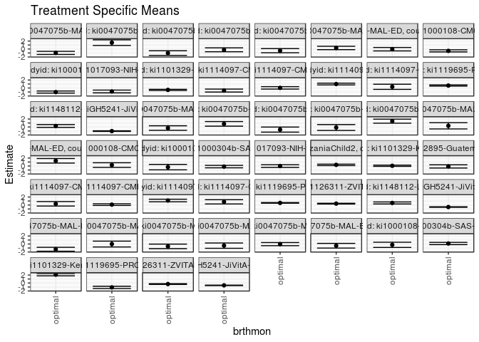

## Results Table

### Parameter: TSM

| agecat | studyid | country | intervention_level | baseline_level | estimate | ci_lower | ci_upper |
| --- | --- | --- | --- | --- | --- | --- | --- |
| Birth | ki0047075b-MAL-ED | BANGLADESH | optimal | observed | -1.3155648 | -1.8034827 | -0.8276469 |
| Birth | ki0047075b-MAL-ED | BRAZIL | optimal | observed | -0.0120865 | -0.7451663 | 0.7209933 |
| Birth | ki0047075b-MAL-ED | INDIA | optimal | observed | -0.5902865 | -1.1561172 | -0.0244558 |
| Birth | ki0047075b-MAL-ED | NEPAL | optimal | observed | -0.4104679 | -1.0793024 | 0.2583666 |
| Birth | ki0047075b-MAL-ED | PERU | optimal | observed | -0.0300745 | -0.4235685 | 0.3634195 |
| Birth | ki0047075b-MAL-ED | SOUTH AFRICA | optimal | observed | -0.4328022 | -1.0191663 | 0.1535619 |
| Birth | ki1000108-IRC | INDIA | optimal | observed | -0.2097715 | -0.8622778 | 0.4427348 |
| Birth | ki1000304b-SAS-CompFeed | INDIA | optimal | observed | 0.1258163 | -0.1554019 | 0.4070345 |
| Birth | ki1101329-Keneba | GAMBIA | optimal | observed | 2.0922747 | 1.8061369 | 2.3784125 |
| Birth | ki1119695-PROBIT | BELARUS | optimal | observed | -1.0931560 | -1.3765365 | -0.8097756 |
| Birth | ki1126311-ZVITAMBO | ZIMBABWE | optimal | observed | -0.2608267 | -0.3561252 | -0.1655282 |
| Birth | kiGH5241-JiVitA-3 | BANGLADESH | optimal | observed | -0.5872947 | -0.6457050 | -0.5288844 |
| 6 months | ki0047075b-MAL-ED | BANGLADESH | optimal | observed | -0.2622528 | -0.8306128 | 0.3061071 |
| 6 months | ki0047075b-MAL-ED | BRAZIL | optimal | observed | 0.7933475 | 0.2137436 | 1.3729514 |
| 6 months | ki0047075b-MAL-ED | INDIA | optimal | observed | -0.6480082 | -1.2831230 | -0.0128934 |
| 6 months | ki0047075b-MAL-ED | NEPAL | optimal | observed | -0.1298987 | -0.8657761 | 0.6059787 |
| 6 months | ki0047075b-MAL-ED | PERU | optimal | observed | 1.4647911 | 0.9597363 | 1.9698460 |
| 6 months | ki0047075b-MAL-ED | SOUTH AFRICA | optimal | observed | 0.3026257 | -0.4818892 | 1.0871407 |
| 6 months | ki0047075b-MAL-ED | TANZANIA, UNITED REPUBLIC OF | optimal | observed | 1.3016469 | 0.7306954 | 1.8725984 |
| 6 months | ki1000108-CMC-V-BCS-2002 | INDIA | optimal | observed | 0.2327411 | -0.3494931 | 0.8149752 |
| 6 months | ki1000108-IRC | INDIA | optimal | observed | -0.2772716 | -0.9569787 | 0.4024355 |
| 6 months | ki1000304b-SAS-CompFeed | INDIA | optimal | observed | -0.1453874 | -0.4532389 | 0.1624642 |
| 6 months | ki1017093-NIH-Birth | BANGLADESH | optimal | observed | -0.0159204 | -0.3590644 | 0.3272235 |
| 6 months | ki1066203-TanzaniaChild2 | TANZANIA, UNITED REPUBLIC OF | optimal | observed | 0.2900564 | 0.1073041 | 0.4728087 |
| 6 months | ki1101329-Keneba | GAMBIA | optimal | observed | 0.0625646 | -0.0877665 | 0.2128957 |
| 6 months | ki1112895-Guatemala BSC | GUATEMALA | optimal | observed | -0.1001835 | -0.5036246 | 0.3032576 |
| 6 months | ki1114097-CMIN | BANGLADESH | optimal | observed | 0.3062685 | -0.2531939 | 0.8657309 |
| 6 months | ki1114097-CMIN | GUINEA-BISSAU | optimal | observed | 0.1025727 | -0.1139135 | 0.3190590 |
| 6 months | ki1114097-CMIN | PERU | optimal | observed | 1.1263977 | 0.8015187 | 1.4512768 |
| 6 months | ki1114097-CONTENT | PERU | optimal | observed | 0.8046191 | 0.2707569 | 1.3384813 |
| 6 months | ki1119695-PROBIT | BELARUS | optimal | observed | 0.5265571 | 0.4450097 | 0.6081045 |
| 6 months | ki1126311-ZVITAMBO | ZIMBABWE | optimal | observed | 0.3475326 | 0.2502494 | 0.4448159 |
| 6 months | ki1148112-LCNI-5 | MALAWI | optimal | observed | 0.5139271 | 0.2629936 | 0.7648605 |
| 6 months | kiGH5241-JiVitA-3 | BANGLADESH | optimal | observed | -0.5112975 | -0.5798371 | -0.4427580 |
| 24 months | ki0047075b-MAL-ED | BANGLADESH | optimal | observed | -0.9758120 | -1.3695598 | -0.5820641 |
| 24 months | ki0047075b-MAL-ED | BRAZIL | optimal | observed | 1.5985305 | 0.8925945 | 2.3044665 |
| 24 months | ki0047075b-MAL-ED | INDIA | optimal | observed | -1.0246679 | -1.6060790 | -0.4432568 |
| 24 months | ki0047075b-MAL-ED | NEPAL | optimal | observed | -0.1939770 | -0.6851000 | 0.2971459 |
| 24 months | ki0047075b-MAL-ED | PERU | optimal | observed | -0.4162544 | -0.9375500 | 0.1050413 |
| 24 months | ki0047075b-MAL-ED | SOUTH AFRICA | optimal | observed | 0.2609132 | -0.1618336 | 0.6836599 |
| 24 months | ki0047075b-MAL-ED | TANZANIA, UNITED REPUBLIC OF | optimal | observed | -0.0455258 | -0.4786312 | 0.3875796 |
| 24 months | ki1000108-CMC-V-BCS-2002 | INDIA | optimal | observed | -0.4657991 | -0.7314244 | -0.2001737 |
| 24 months | ki1000108-IRC | INDIA | optimal | observed | -1.0202004 | -1.2831395 | -0.7572613 |
| 24 months | ki1017093-NIH-Birth | BANGLADESH | optimal | observed | -0.8706842 | -1.2199332 | -0.5214353 |
| 24 months | ki1101329-Keneba | GAMBIA | optimal | observed | -0.4728843 | -0.6166518 | -0.3291169 |
| 24 months | ki1114097-CMIN | BANGLADESH | optimal | observed | -0.6451050 | -1.0157744 | -0.2744355 |
| 24 months | ki1114097-CMIN | GUINEA-BISSAU | optimal | observed | 0.0335508 | -0.2710579 | 0.3381596 |
| 24 months | ki1114097-CMIN | PERU | optimal | observed | 0.9970892 | 0.7794032 | 1.2147753 |
| 24 months | ki1114097-CONTENT | PERU | optimal | observed | 0.3050296 | -0.3399216 | 0.9499808 |
| 24 months | ki1119695-PROBIT | BELARUS | optimal | observed | 0.6188880 | 0.4663790 | 0.7713971 |
| 24 months | ki1148112-LCNI-5 | MALAWI | optimal | observed | 0.2525686 | -0.0987883 | 0.6039255 |
| 24 months | kiGH5241-JiVitA-3 | BANGLADESH | optimal | observed | -1.0280801 | -1.1011346 | -0.9550256 |

### Parameter: E(Y)

| agecat | studyid | country | intervention_level | baseline_level | estimate | ci_lower | ci_upper |
| --- | --- | --- | --- | --- | --- | --- | --- |
| Birth | ki0047075b-MAL-ED | BANGLADESH | observed | observed | -0.9630705 | -1.0989132 | -0.8272278 |
| Birth | ki0047075b-MAL-ED | BRAZIL | observed | observed | 0.4038798 | 0.2296279 | 0.5781316 |
| Birth | ki0047075b-MAL-ED | INDIA | observed | observed | -1.0691133 | -1.2078629 | -0.9303637 |
| Birth | ki0047075b-MAL-ED | NEPAL | observed | observed | -0.9044643 | -1.0439568 | -0.7649718 |
| Birth | ki0047075b-MAL-ED | PERU | observed | observed | -0.0735842 | -0.1836203 | 0.0364518 |
| Birth | ki0047075b-MAL-ED | SOUTH AFRICA | observed | observed | -0.0562791 | -0.2000837 | 0.0875255 |
| Birth | ki1000108-IRC | INDIA | observed | observed | -1.0105831 | -1.1973019 | -0.8238643 |
| Birth | ki1000304b-SAS-CompFeed | INDIA | observed | observed | -0.2697590 | -0.5399211 | 0.0004030 |
| Birth | ki1101329-Keneba | GAMBIA | observed | observed | 1.7036191 | 1.6208471 | 1.7863911 |
| Birth | ki1119695-PROBIT | BELARUS | observed | observed | -1.1463469 | -1.3562674 | -0.9364264 |
| Birth | ki1126311-ZVITAMBO | ZIMBABWE | observed | observed | -0.5151425 | -0.5409938 | -0.4892911 |
| Birth | kiGH5241-JiVitA-3 | BANGLADESH | observed | observed | -0.7240996 | -0.7439385 | -0.7042607 |
| 6 months | ki0047075b-MAL-ED | BANGLADESH | observed | observed | -0.1397960 | -0.2688682 | -0.0107238 |
| 6 months | ki0047075b-MAL-ED | BRAZIL | observed | observed | 0.9717225 | 0.8073791 | 1.1360658 |
| 6 months | ki0047075b-MAL-ED | INDIA | observed | observed | -0.7033969 | -0.8285284 | -0.5782654 |
| 6 months | ki0047075b-MAL-ED | NEPAL | observed | observed | 0.1110452 | -0.0202712 | 0.2423616 |
| 6 months | ki0047075b-MAL-ED | PERU | observed | observed | 1.0543956 | 0.9326967 | 1.1760945 |
| 6 months | ki0047075b-MAL-ED | SOUTH AFRICA | observed | observed | 0.5420735 | 0.3899459 | 0.6942011 |
| 6 months | ki0047075b-MAL-ED | TANZANIA, UNITED REPUBLIC OF | observed | observed | 0.5170513 | 0.3872178 | 0.6468847 |
| 6 months | ki1000108-CMC-V-BCS-2002 | INDIA | observed | observed | -0.5026766 | -0.6536848 | -0.3516685 |
| 6 months | ki1000108-IRC | INDIA | observed | observed | -0.5989297 | -0.7344491 | -0.4634104 |
| 6 months | ki1000304b-SAS-CompFeed | INDIA | observed | observed | -0.6657084 | -0.8024377 | -0.5289791 |
| 6 months | ki1017093-NIH-Birth | BANGLADESH | observed | observed | -0.4389101 | -0.5279432 | -0.3498771 |
| 6 months | ki1066203-TanzaniaChild2 | TANZANIA, UNITED REPUBLIC OF | observed | observed | 0.0809332 | 0.0282644 | 0.1336020 |
| 6 months | ki1101329-Keneba | GAMBIA | observed | observed | -0.1846223 | -0.2354964 | -0.1337483 |
| 6 months | ki1112895-Guatemala BSC | GUATEMALA | observed | observed | -0.0840134 | -0.1945572 | 0.0265305 |
| 6 months | ki1114097-CMIN | BANGLADESH | observed | observed | -0.5780453 | -0.7226627 | -0.4334279 |
| 6 months | ki1114097-CMIN | GUINEA-BISSAU | observed | observed | -0.0418080 | -0.1199942 | 0.0363782 |
| 6 months | ki1114097-CMIN | PERU | observed | observed | 0.6721017 | 0.5829735 | 0.7612299 |
| 6 months | ki1114097-CONTENT | PERU | observed | observed | 1.0684318 | 0.9515274 | 1.1853362 |
| 6 months | ki1119695-PROBIT | BELARUS | observed | observed | 0.5789633 | 0.5190130 | 0.6389137 |
| 6 months | ki1126311-ZVITAMBO | ZIMBABWE | observed | observed | 0.3047138 | 0.2786437 | 0.3307839 |
| 6 months | ki1148112-LCNI-5 | MALAWI | observed | observed | 0.4499285 | 0.3788279 | 0.5210291 |
| 6 months | kiGH5241-JiVitA-3 | BANGLADESH | observed | observed | -0.5935161 | -0.6130518 | -0.5739805 |
| 24 months | ki0047075b-MAL-ED | BANGLADESH | observed | observed | -0.8208255 | -0.9429246 | -0.6987264 |
| 24 months | ki0047075b-MAL-ED | BRAZIL | observed | observed | 0.4466272 | 0.2416144 | 0.6516401 |
| 24 months | ki0047075b-MAL-ED | INDIA | observed | observed | -0.9522907 | -1.0676596 | -0.8369219 |
| 24 months | ki0047075b-MAL-ED | NEPAL | observed | observed | -0.3764474 | -0.4898516 | -0.2630431 |
| 24 months | ki0047075b-MAL-ED | PERU | observed | observed | 0.1199005 | -0.0000331 | 0.2398341 |
| 24 months | ki0047075b-MAL-ED | SOUTH AFRICA | observed | observed | 0.4267017 | 0.3074751 | 0.5459283 |
| 24 months | ki0047075b-MAL-ED | TANZANIA, UNITED REPUBLIC OF | observed | observed | 0.0500935 | -0.0748234 | 0.1750103 |
| 24 months | ki1000108-CMC-V-BCS-2002 | INDIA | observed | observed | -0.5571505 | -0.6585247 | -0.4557763 |
| 24 months | ki1000108-IRC | INDIA | observed | observed | -0.7458150 | -0.8368180 | -0.6548120 |
| 24 months | ki1017093-NIH-Birth | BANGLADESH | observed | observed | -0.9115790 | -1.0095022 | -0.8136559 |
| 24 months | ki1101329-Keneba | GAMBIA | observed | observed | -0.8099290 | -0.8570608 | -0.7627972 |
| 24 months | ki1114097-CMIN | BANGLADESH | observed | observed | -0.8535391 | -0.9644236 | -0.7426546 |
| 24 months | ki1114097-CMIN | GUINEA-BISSAU | observed | observed | -0.1442438 | -0.2323415 | -0.0561461 |
| 24 months | ki1114097-CMIN | PERU | observed | observed | 0.6477778 | 0.5676685 | 0.7278870 |
| 24 months | ki1114097-CONTENT | PERU | observed | observed | 0.5668293 | 0.4302437 | 0.7034148 |
| 24 months | ki1119695-PROBIT | BELARUS | observed | observed | 0.6863435 | 0.5745700 | 0.7981170 |
| 24 months | ki1148112-LCNI-5 | MALAWI | observed | observed | -0.0478508 | -0.1297321 | 0.0340305 |
| 24 months | kiGH5241-JiVitA-3 | BANGLADESH | observed | observed | -1.2978031 | -1.3210763 | -1.2745298 |

### Parameter: PAR

| agecat | studyid | country | intervention_level | baseline_level | estimate | ci_lower | ci_upper |
| --- | --- | --- | --- | --- | --- | --- | --- |
| Birth | ki0047075b-MAL-ED | BANGLADESH | optimal | observed | 0.3524943 | -0.1110860 | 0.8160745 |
| Birth | ki0047075b-MAL-ED | BRAZIL | optimal | observed | 0.4159663 | -0.2933514 | 1.1252839 |
| Birth | ki0047075b-MAL-ED | INDIA | optimal | observed | -0.4788268 | -1.0178856 | 0.0602320 |
| Birth | ki0047075b-MAL-ED | NEPAL | optimal | observed | -0.4939964 | -1.1433296 | 0.1553368 |
| Birth | ki0047075b-MAL-ED | PERU | optimal | observed | -0.0435097 | -0.4307398 | 0.3437203 |
| Birth | ki0047075b-MAL-ED | SOUTH AFRICA | optimal | observed | 0.3765232 | -0.1836572 | 0.9367035 |
| Birth | ki1000108-IRC | INDIA | optimal | observed | -0.8008116 | -1.4233897 | -0.1782335 |
| Birth | ki1000304b-SAS-CompFeed | INDIA | optimal | observed | -0.3955753 | -0.7865737 | -0.0045770 |
| Birth | ki1101329-Keneba | GAMBIA | optimal | observed | -0.3886556 | -0.6677380 | -0.1095731 |
| Birth | ki1119695-PROBIT | BELARUS | optimal | observed | -0.0531909 | -0.1999624 | 0.0935806 |
| Birth | ki1126311-ZVITAMBO | ZIMBABWE | optimal | observed | -0.2543158 | -0.3459970 | -0.1626346 |
| Birth | kiGH5241-JiVitA-3 | BANGLADESH | optimal | observed | -0.1368049 | -0.1908646 | -0.0827452 |
| 6 months | ki0047075b-MAL-ED | BANGLADESH | optimal | observed | 0.1224569 | -0.4372401 | 0.6821539 |
| 6 months | ki0047075b-MAL-ED | BRAZIL | optimal | observed | 0.1783750 | -0.3948291 | 0.7515792 |
| 6 months | ki0047075b-MAL-ED | INDIA | optimal | observed | -0.0553887 | -0.6679418 | 0.5571644 |
| 6 months | ki0047075b-MAL-ED | NEPAL | optimal | observed | 0.2409439 | -0.4620445 | 0.9439323 |
| 6 months | ki0047075b-MAL-ED | PERU | optimal | observed | -0.4103955 | -0.8916445 | 0.0708534 |
| 6 months | ki0047075b-MAL-ED | SOUTH AFRICA | optimal | observed | 0.2394478 | -0.5309456 | 1.0098411 |
| 6 months | ki0047075b-MAL-ED | TANZANIA, UNITED REPUBLIC OF | optimal | observed | -0.7845956 | -1.3455228 | -0.2236685 |
| 6 months | ki1000108-CMC-V-BCS-2002 | INDIA | optimal | observed | -0.7354177 | -1.2763800 | -0.1944554 |
| 6 months | ki1000108-IRC | INDIA | optimal | observed | -0.3216581 | -0.9804195 | 0.3371032 |
| 6 months | ki1000304b-SAS-CompFeed | INDIA | optimal | observed | -0.5203210 | -0.7095357 | -0.3311064 |
| 6 months | ki1017093-NIH-Birth | BANGLADESH | optimal | observed | -0.4229897 | -0.7531107 | -0.0928686 |
| 6 months | ki1066203-TanzaniaChild2 | TANZANIA, UNITED REPUBLIC OF | optimal | observed | -0.2091233 | -0.3856634 | -0.0325831 |
| 6 months | ki1101329-Keneba | GAMBIA | optimal | observed | -0.2471869 | -0.3880785 | -0.1062953 |
| 6 months | ki1112895-Guatemala BSC | GUATEMALA | optimal | observed | 0.0161701 | -0.3704688 | 0.4028090 |
| 6 months | ki1114097-CMIN | BANGLADESH | optimal | observed | -0.8843138 | -1.4249445 | -0.3436831 |
| 6 months | ki1114097-CMIN | GUINEA-BISSAU | optimal | observed | -0.1443807 | -0.3463023 | 0.0575409 |
| 6 months | ki1114097-CMIN | PERU | optimal | observed | -0.4542961 | -0.7708560 | -0.1377361 |
| 6 months | ki1114097-CONTENT | PERU | optimal | observed | 0.2638127 | -0.2455273 | 0.7731527 |
| 6 months | ki1119695-PROBIT | BELARUS | optimal | observed | 0.0524062 | -0.0265518 | 0.1313642 |
| 6 months | ki1126311-ZVITAMBO | ZIMBABWE | optimal | observed | -0.0428188 | -0.1347540 | 0.0491163 |
| 6 months | ki1148112-LCNI-5 | MALAWI | optimal | observed | -0.0639986 | -0.3128254 | 0.1848283 |
| 6 months | kiGH5241-JiVitA-3 | BANGLADESH | optimal | observed | -0.0822186 | -0.1472338 | -0.0172034 |
| 24 months | ki0047075b-MAL-ED | BANGLADESH | optimal | observed | 0.1549865 | -0.2252416 | 0.5352146 |
| 24 months | ki0047075b-MAL-ED | BRAZIL | optimal | observed | -1.1519033 | -1.8475034 | -0.4563031 |
| 24 months | ki0047075b-MAL-ED | INDIA | optimal | observed | 0.0723771 | -0.4809410 | 0.6256953 |
| 24 months | ki0047075b-MAL-ED | NEPAL | optimal | observed | -0.1824703 | -0.6543702 | 0.2894295 |
| 24 months | ki0047075b-MAL-ED | PERU | optimal | observed | 0.5361549 | 0.0343325 | 1.0379772 |
| 24 months | ki0047075b-MAL-ED | SOUTH AFRICA | optimal | observed | 0.1657885 | -0.2424818 | 0.5740588 |
| 24 months | ki0047075b-MAL-ED | TANZANIA, UNITED REPUBLIC OF | optimal | observed | 0.0956193 | -0.3154186 | 0.5066572 |
| 24 months | ki1000108-CMC-V-BCS-2002 | INDIA | optimal | observed | -0.0913515 | -0.3522613 | 0.1695584 |
| 24 months | ki1000108-IRC | INDIA | optimal | observed | 0.2743854 | 0.0147669 | 0.5340040 |
| 24 months | ki1017093-NIH-Birth | BANGLADESH | optimal | observed | -0.0408948 | -0.3777296 | 0.2959399 |
| 24 months | ki1101329-Keneba | GAMBIA | optimal | observed | -0.3370446 | -0.4747033 | -0.1993860 |
| 24 months | ki1114097-CMIN | BANGLADESH | optimal | observed | -0.2084341 | -0.5785194 | 0.1616511 |
| 24 months | ki1114097-CMIN | GUINEA-BISSAU | optimal | observed | -0.1777946 | -0.4720210 | 0.1164318 |
| 24 months | ki1114097-CMIN | PERU | optimal | observed | -0.3493115 | -0.5613952 | -0.1372278 |
| 24 months | ki1114097-CONTENT | PERU | optimal | observed | 0.2617997 | -0.3596349 | 0.8832343 |
| 24 months | ki1119695-PROBIT | BELARUS | optimal | observed | 0.0674555 | -0.0634825 | 0.1983934 |
| 24 months | ki1148112-LCNI-5 | MALAWI | optimal | observed | -0.3004194 | -0.6444942 | 0.0436553 |
| 24 months | kiGH5241-JiVitA-3 | BANGLADESH | optimal | observed | -0.2697230 | -0.3403693 | -0.1990767 |